# Ebola Cases in Guinea

## Measurment Model

We build the POMP model like below:

```r
sir_step <- Csnippet("
  double dN_SI = rbinom(S,1-exp(-Beta*I/N*dt));
  double dN_IR = rbinom(I,1-exp(-gamma*dt));
  S -= dN_SI;
  I += dN_SI - dN_IR;
  R += dN_IR;
")

sir_rinit <- Csnippet("
  S = N-1;
  I = 1;
  R = 0;
")

pomp(subset(ebola,select=c(day,value)),
     time="day",t0=1,rprocess=euler(sir_step,delta.t=1/6),
     rinit=sir_rinit,paramnames=c("N","Beta","gamma"),
     statenames=c("S","I","R")) -> sir

sir_step <- Csnippet("
  double dN_SI = rbinom(S,1-exp(-Beta*I/N*dt));
  double dN_IR = rbinom(I,1-exp(-gamma*dt));
  S -= dN_SI;
  I += dN_SI - dN_IR;
  R += dN_IR;
  H += dN_IR;
")

sir_rinit <- Csnippet("
  S = N-1;
  I = 1;
  R = 0;
  H = 0;
")

pomp(sir,rprocess=euler(sir_step,delta.t=1/6),rinit=sir_rinit,
     paramnames=c("Beta","gamma","N"),
     statenames=c("S","I","R","H")) -> sir

pomp(sir,accumvars="H") -> sir

dmeas <- Csnippet("lik = dbinom(value,H,rho,give_log);")
rmeas <- Csnippet("value = rbinom(H,rho);")

sir <- pomp(sir,rmeasure=rmeas,dmeasure=dmeas,
  statenames="H",paramnames="rho")
```

## Simulation

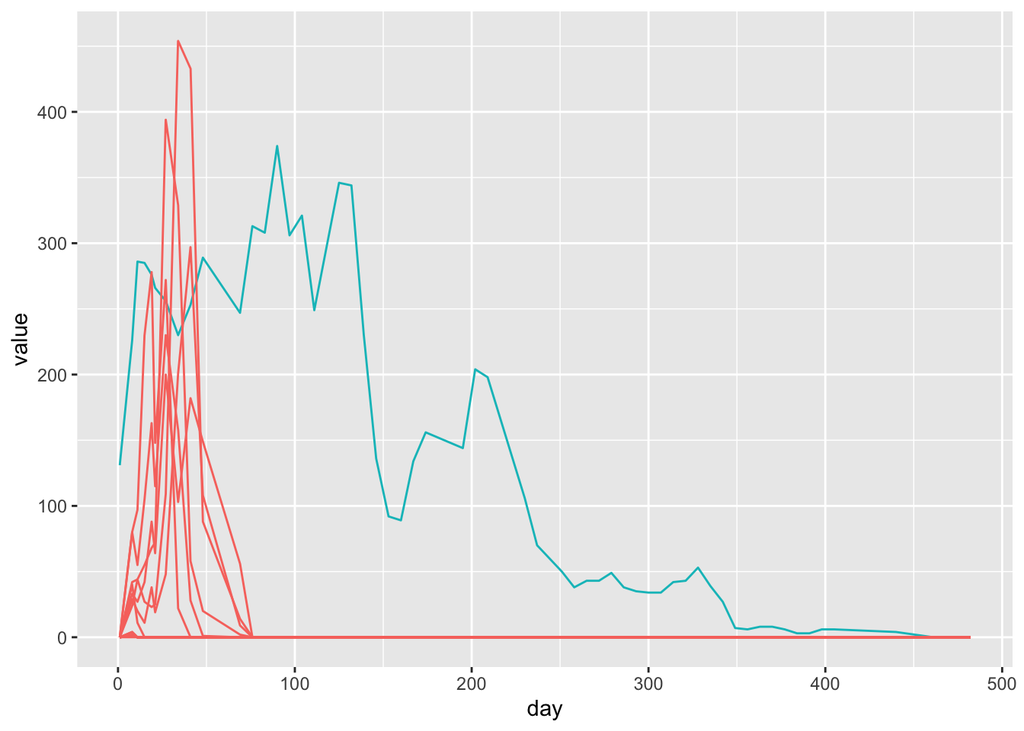

```r
sims <- simulate(sir,params=c(Beta=1.2,gamma=1,rho=0.9,N=2600),
                 nsim=20,format="data.frame",include=TRUE)
ggplot(sims,mapping=aes(x=day,y=value,group=.id,color=.id=="data"))+
  geom_line()+guides(color=FALSE)
```

# Conclusion

From diagonosis analysis, ARIMA(2,0,2) is not the best model fit for confirmed ebola data, however it still shows the pattern of the confirmed ebola cases which is increasing in the first half the period and a significant decreasing trend in the latter half.

# Source

[1] Ebola virus epidemic in Guinea https://en.wikipedia.org/wiki/Ebola_virus_epidemic_in_Guinea [2] “Ebola (Ebola Virus Disease).” Centers for Disease Control and Prevention, Centers for Disease Control and Prevention, 22 June 2016, www.cdc.gov/vhf/ebola/outbreaks/2014-west-africa/index.html. [3] Ebola data in record format with indicator, country, date and value, www.kaggle.com/kingburrito666/ebola-cases. [4] 2014-2016 Ebola Outbreak in West Africa https://www.cdc.gov/vhf/ebola/history/2014-2016-outbreak/index.html